# R-eproducible Psychological Science

2018-07-25 08:22:17

## Themes

1. Is there a reproducibility crisis?
2. What does reproducible psychological science look like?
3. How can R & RStudio make my science more transparent, open, and reproducible?

## Is there a reproducibility crisis?

[video not shown]

## Is there a reproducibility crisis?

- Yes, a significant crisis
- Yes, a slight crisis
- No crisis
- Don't know

[figure not shown]

[Baker 2016](http://doi.org/10.1038/533452a)

## Results from our own bootcamp poll

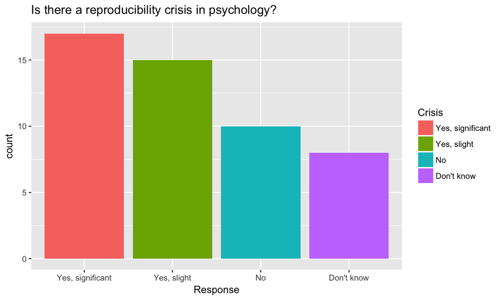

## Not just in psychology

[figure not shown]

[Baker 2016](http://doi.org/10.1038/533452a)

## [(Munafò et al. 2017)](http://doi.org/10.1038/s41562-016-0021) manifesto

[figure not shown]

## What does reproducible science look like?

## What am I trying to reproduce?

- My own workflow
  - Data collection
  - Cleaning
  - Visualization
  - Analysis
  - Reporting
  - Manuscript generation?

## What am I trying to avoid?

- "Hit by a truck" scenario

[figure not shown]

## Reproducible workflows

- Scripted, automated = minimize human-dependent steps.
- Well-documented
- Be kind to your future (forgetful) self
- Transparent to me & colleagues == transparent to others

## Reproducible workflows (the future)

- Data, materials openly (and securely) shared with researchers
  - Including procedure videos [(Gilmore and Adolph 2017)](http://doi.org/10.1038/s41562-017-0128)
- Data, materials (displays, code) stored in central repository
  - Open Science Framework ([OSF](http://osf.io))
  - [Databrary](http://databrary.org)

## Reproducible workflows (the future)

- Access/analyze materials/displays via repository application program interfaces (APIs)
- Building a 'cumulative' science [(Mischel 2011)](https://www.psychologicalscience.org/observer/becoming-a-cumulative-science)

## How R can make my science more reproducible

## Using R scripts for reproducible workflows

```
# Import/gather data

# Clean data

# Visualize data

# Analyze data

# Report findings
```

```
# Import data
my_data <- read.csv("path/2/data_file.csv")

# Clean data
my_data$gender <- tolower(my_data$gender) # make lower case
...
```

## Script calls sequence of R commands or functions

```
# Import data
source("R/Import_data.R") # source() runs scripts, loads functions

# Clean data
source("R/Clean_data.R")

# Visualize data
source("R/Visualize_data.R")
...
```

## Strengths & Weaknesses

- R commands in files that can be re-run
- Separate pieces of workflow kept separate
- "Master.R" script that can be run to regenerate full sequence of results
  - Error in raw data file?
  - No problem; fix data file and re-run "Master.R"
- How to save results or share with collaborators?

## Use R & RStudio for earlier phases?

[figure not shown]

[(Munafò et al. 2017)](http://doi.org/10.1038/s41562-016-0021) manifesto

## RStudio projects

- Create using 'File/New Project'
- Store in new directory with sensible name ('projects/1st_year_proj')
- Creates *.Rproj file
- Turn-off saving data to the .RData file
- 'File/Open Project…' command opens 'fresh' workspace

## RStudio Projects

- Keep files, settings, organized
- Easy to switch between projects
- Reduces mental effort (what directory am I in?)
  - Avoid `setwd()` commands that only work on *your* computer
- Integrates with version control (e.g., GitHub)

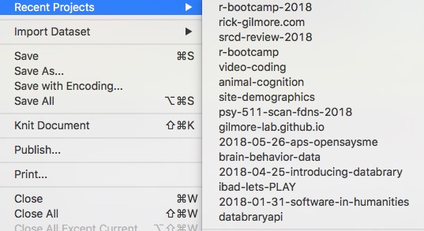

## R Markdown workflow

- Combine text, R code, images, comments, videos into one document
- Render as web page (or site), PDF, MS Word (.docx), slides, etc.

## What is R Markdown?

- Markdown is a scripting 'language' used in lots of blogging engines and wikis
  - Simple commands to format documents
  - Designed to be easier than writing in raw HTML
- Human & machine readable
- [R Markdown](https://rmarkdown.rstudio.com/) extends Markdown with commands specialized for R code

```
# Big idea

## Smaller idea in service of bigger

- Supporting point
- Another suppporting point

1. an enumerated **bold** point
1. an enumerated *italicized* point
```

## Big idea

## Smaller idea in service of bigger

```
- a [link](http://psu-psychology.github.io/r-bootcamp) to this bootcamp
- an image: ![rawr](https://www.insidehighered.com/sites/default/server_files/media/PennState2.PNG)
- an equation: $e = mc^2$
```

- a [link](http://psu-psychology.github.io/r-bootcamp) to this bootcamp
- an image:

[figure not shown]

- an equation: \(e = mc^2\)

```
# Some R code
ggplot2::qplot(rnorm(100))
```

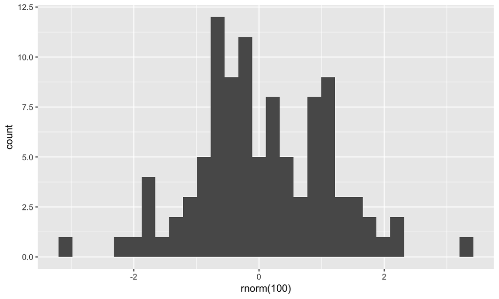

```r
# Some R code
ggplot2::qplot(rnorm(100))
```

## One R to rule them all and in the console bind them…

- One file, many possible outputs
  - [pdf_document](http://rmarkdown.rstudio.com/pdf_document_format.html), [word_document](http://rmarkdown.rstudio.com/word_document_format.html), or [github_document](http://rmarkdown.rstudio.com/github_document_format.html)
  - [ioslides_presentation](http://rmarkdown.rstudio.com/ioslides_presentation_format.html) for HTML slide show
  - Cool interactive web-apps in Shiny
  - Web sites like the one for this [bootcamp](https://github.com/psu-psychology/r-bootcamp-2018), [blogs](https://bookdown.org/yihui/blogdown/), even [books](https://bookdown.org/yihui/bookdown/)

## Let's look at a real example some

- bootcamp-survey.Rmd

## One file, many output options

- 'Default' for the file: `rmarkdown::render("talks/bootcamp-survey.Rmd")`
- **PDF document**: `rmarkdown::render('talks/bootcamp-survey.Rmd', output_format = "pdf_document")`
- **Word document**: `rmarkdown::render('talks/bootcamp-survey.Rmd', output_format = "word_document")`
- **HTML slides**: `rmarkdown::render('talks/bootcamp-survey.Rmd', output_format = "ioslides_presentation")`
- **Multiple outputs**: `rmarkdown::render('talks/bootcamp-survey.Rmd', output_format = c("pdf_document", "word_document", "github_document", "ioslides_presentation")`

## Key points

- Use R scripts to capture & reproduce workflows and/or
- Use R Markdown files for documents, reports, presentations.
  - One or more output formats from the same file.
  - Analysis/lab notebook.
- Use R scripts or functions to automate different pieces of the pipeline.
- Make README files to explain how to put pieces together.

[figure not shown]

## Toward a reproducible psychological science…

- Transparent, reproducible, open workflows pre-publication
- Openly shared materials + data + code
- [(Munafò et al. 2017)](http://doi.org/10.1038/s41562-016-0021): reproducible practices across the workflow
  - Where to share and when? Lots of options. Let's talk.
- [(Gilmore and Adolph 2017)](http://dx.doi.org/10.1038/s41562-017-0128): video and reproducibility

## Advanced topics

- Write papers in R Markdown using [`papaja`](https://github.com/crsh/papaja)
  - Make this from this
- Version control with git and [GitHub](http://github.com)
- Scriptable analysis workflows
  - Reports for each participant, e.g. [PEEP-II project](https://github.com/gilmore-lab/peep-II-ratings-analysis)
  - This bootcamp's `Make_site.R`
- [Web sites](http://rmarkdown.rstudio.com/rmarkdown_websites.html), [blogs](https://bookdown.org/yihui/blogdown/), (even [books](https://bookdown.org/)) with R Markdown

## Version control

- Keep track of your past
- Back to the Future
- **git**: a system for software version control
- [**GitHub**](http://github.com): a website for managing projects that use git

## My GitHub workflow

1. Create a repo on GitHub
2. Copy repo URL
3. `File/New Project.../`
4. Version Control, Git
5. Paste repo URL
6. Select local name for repo and directory where it lives.
7. Open project within R Studio `File/Open Project...`
8. Commit early & often

[video not shown]

## Scripting the pipeline

```
# Get_bootcamp_googlesheet.R
#
# Script to authenticate to Google, extract R bootcamp survey data

library(googlesheets)
library(tidyverse)

survey_url <- "https://docs.google.com/spreadsheets/d/1Ay56u6g4jyEEdlmV2NHxTLBlcjI2gHavta-Ik0kGrpg/edit?usp=sharing"

bootcamp_by_url <- survey_url %>%
  extract_key_from_url() %>%
  gs_key()

bootcamp_sheets <- gs_ws_ls(bootcamp_by_url)
```

```
boot_data <- bootcamp_by_url %>%
  gs_read(bootcamp_sheets[1])

names(boot_data) <- c("Timestamp",
                      "R_exp",
                      "GoT",
                      "Age_yrs",
                      "Sleep_hrs",
                      "Fav_date",
                      "Tidy_data")

write_csv(boot_data, path = "data/survey.csv")
```

```
# Update_survey.R
#
# Updates Googlesheet survey data and generates new R Markdown report
#

source("R/Get_bootcamp_googlesheet.R")
rmarkdown::render("talks/bootcamp-survey.Rmd",
                  output_format = c("github_document",
                                    "pdf_document",
                                    "word_document",
                                    "ioslides_presentation"))
```

## [Web sites](http://rmarkdown.rstudio.com/rmarkdown_websites.html)

- `_site.yml`: site configuration parameters
- `index.Rmd`: home page for site
- other `*.Rmd` files: other pages
- other directories for files
- `rmarkdown::render_site()`
- [GitHub pages](https://pages.github.com/) or other web site hosting service

## Learn from my mistakes

- Script **everything** you possibly can
  - If you have to repeat something, make a function or write a parameterized script
- Document **all the time**
  - Comments in code
  - Update README files
- Don't be afraid to ask
- Don't be afraid to work in the open
- Learn from others
- Just do it!

## References

Gilmore, R O, and K E Adolph. 2017. “Video Can Make Behavioural Science More Reproducible.” *Nature Human Behavior* 1 (12~jun). doi:10.1038/s41562-017-0128.

Mischel, Walter. 2011. “Becoming a Cumulative Science.” *APS Observer* 22 (1). https://www.psychologicalscience.org/observer/becoming-a-cumulative-science.

Munafò, Marcus R, Brian A Nosek, Dorothy V M Bishop, Katherine S Button, Christopher D Chambers, Nathalie Percie du Sert, Uri Simonsohn, Eric-Jan Wagenmakers, Jennifer J Ware, and John P A Ioannidis. 2017. “A Manifesto for Reproducible Science.” *Nature Human Behaviour* 1 (10~jan): 0021. doi:10.1038/s41562-016-0021.